This code imports the libraries and modules that will be used for this notebook.

```python
from IPython.display import HTML, display
import geopandas as gpd
import matplotlib.pyplot as plt
import pandas as pd
import re
import pickle
from pathlib import Path
import pyproj
import numpy as np
import json
import os
import pickle

# # Standard plotly imports
# import plotly
# import plotly.plotly as py
# import plotly.graph_objs as go
# from plotly.offline import iplot, init_notebook_mode

# # Using plotly + cufflinks in offline mode
# import cufflinks
# cufflinks.go_offline(connected=True)
# init_notebook_mode(connected=True)

from IPython.display import HTML, display
%matplotlib inline
```

```python
import sys
sys.path.append('../election2019')

from election2019.config import shp_dir, contests_path, results_path, census_dir
from election2019.functions import fetch_files, sorter
```

# 2019 Philippine National Election Stories: An Anthology

With the recently concluded elections, the Filipino people have selected their newest set of 12 Senators of the Republic.

We now present a collection of 7 mini-stories that we hope will give you greater insights on the recently concluded 2019 Philippine National Elections.

## Table of Contents

### Section 1. Data Mining

### Section 2. Top 12 Senatorial Candidates of the 2019 Election

### Section 3. Stories

#### Story 1. Performance by Affiliation

#### Story 2. Voter Turnout

#### Story 3. Literacy and Political Preference

#### Story 4. Candidates' Performance by Region

#### Story 5. Performance of HNP and OTSO by Region

#### Story 6. Influence of the INC

#### Story 7. The Home-Court Advantage

## Section 1. Data Mining

The data is contained in the `results_path` folder. It is organized in the following manner:

- REGION
- PROVINCE
- MUNICIPALITY/CITY
- BARANGAY
- [JSON FILES]

The data is stored in various JSON files. Each JSON file represents the returns from one machine.

In the following cell is an excerpt from one of the JSON files.

```python
sample_path = results_path / 'REGION VI' /\
    'NEGROS OCCIDENTAL/BACOLOD CITY/BARANGAY  4 (POB.)/45010012.json'
sample_json = json.load(open(sample_path))
print('Key `cos`:\n')
print(sample_json['cos'][:10])
print('\n\nKey `rs`:\n')
print(sample_json['rs'][:10])
```

```
Key `cos`:

[{'cc': 1, 'cn': 'blank', 'ct': 18}, {'cc': 1, 'cn': 'blank-ballots', 'ct': 2}, {'cc': 1, 'cn': 'expected-voters', 'ct': 816}, {'cc': 1, 'cn': 'misfeed-ballots', 'ct': 15}, {'cc': 1, 'cn': 'number-of-voters-who-actually-voted', 'ct': 669}, {'cc': 1, 'cn': 'overvote-ballots', 'ct': 56}, {'cc': 1, 'cn…


Key `rs`:

[{'cc': 1, 'bo': 1, 'v': 15, 'tot': 6017, 'per': '0.24', 'ser': 'HPM180PA01059803'}, {'cc': 1, 'bo': 2, 'v': 18, 'tot': 6017, 'per': '0.29', 'ser': 'HPM180PA01059803'}, {'cc': 1, 'bo': 3, 'v': 32, 'tot': 6017, 'per': '0.53', 'ser': 'HPM180PA01059803'}, {'cc': 1, 'bo': 4, 'v': 9, 'tot': 6017, 'per': …
```

Under key `cos` there is some useful information about the electoral process for that machine, including number of voters who actually voted, overvotes, undervotes, etc.  
However, the results are under key `rs` which likely stands for results.  
In the following cell, we will explore one element of data in `rs` of `45010012.json`.

```python
sample_json['rs'][0]
```

```
{'cc': 1,
 'bo': 1,
 'v': 15,
 'tot': 6017,
 'per': '0.24',
 'ser': 'HPM180PA01059803'}
```

`bo`: a unique identifier for each candidate. `bo` 1-62 represent the senatorial candidates in alphabetical order; thus, `bo`: 1 is Vangie Abejo and `bo`: 62 is Cynthia Villar.  
`tot`: total number of votes obtained by all candidates.  
`v`: number of votes obtained by candidate referred to by `bo`.  
`per`: v divided by tot. Misleading for positions with multiple seats.  
`ser`: likely the serial number of the vote counting machine.

The following code will read the Election Result Data from the Election Return files which were downloaded from the COMELEC Transparency Server during the period May 14 to 17, 2019.

(Note: This process may take about 10 minutes to complete.)

```python
results = []
vote_count_n = np.array(np.zeros(65, dtype=int))
# pattern = re.compile(r'^/.+?/results/(.+?)/(.+?)/(.+?)/(.+?)$')
empty_zone_log = ''

for root, dirs, files in \
    os.walk(results_path):

    if len(dirs) == 0:
        path_obj = Path(root).parts
        res = []
        # Region
        res.append(path_obj[4])
        # Province
        res.append(path_obj[5])
        # City/Municipality
        res.append(path_obj[6])
        # Barangay/Zone (optional)
        try:
            res.append(path_obj[7])
        except IndexError:
            # Pass, but count number of occurrences of this situation
            res.append('BLANK')
            log_message = f'Empty directory in {path_obj[4]}/{path_obj[5]}/{path_obj[6]}'
            empty_zone_log += log_message + '\n'
        vote_count_b = np.array(np.zeros(65, dtype=int))
        for file in files:
            if file != 'info.json':
#                 data = json.loads(open(root + '/' + file).read())
                data = json.load(open(Path(root) / file))
                data_rs = data['rs']

                vote_count = np.array(np.zeros(65, dtype=int))
                for data_bo in data_rs:
                    vote_count[int(data_bo['bo'])] += int(data_bo['v'])
                    if int(data_bo['bo']) >= 62:
                        break
                if len(data['cos']) > 5:
                    vote_count[63] = int(data['cos'][4]['ct'])
                    vote_count[64] = int(data['cos'][2]['ct'])
                vote_count_b += vote_count

        res.append(vote_count_b)
        results.append(res)

        vote_count_n += vote_count_b
```

#### The following sets of codes will generate and structure the data required for the analysis and reports.

This code will structure the Barangay Level and the National Level Results into a DataFrame.

```python
results_df1 = pd.DataFrame.from_records([res[0:4] for res in results],
                                        columns=['region', 'province', \
                                                 'city', 'barangay'])
results_df2 = pd.DataFrame.from_records([res[4] for res in results],
                                        columns=range(65))
results_df2.drop(0, axis=1, inplace=True)
results_df2
results_df = pd.concat([results_df1, results_df2], axis=1)

vote_count_n_df = pd.DataFrame.from_records(data=[vote_count_n[1:]],
                                            columns=range(1,65))
vote_count_n_df.index = ['PHILIPPINES']
```

This code will produce the Regional Level Results.

```python
results_r_df = results_df.groupby(['region']).agg(dict(zip(list(range(1,65)),
                                                           ['sum']*64)))
```

```python
region_list = [
    'REGION I',
    'REGION II',
    'REGION III',
    'REGION IV-A',
    'REGION IV-B',
    'REGION V',
    'REGION VI',
    'REGION VII',
    'REGION VIII',
    'REGION IX',
    'REGION X',
    'REGION XI',
    'REGION XII',
    'REGION XIII',
    'BARMM',
    'CAR',
    'NCR',
    'OAV']
```

This code loads the data that will be used to create the map of the Philippines.

```python
fp = shp_dir / 'Regions.shp'
map_df = gpd.read_file(fp)
for c in range(len(map_df)):
    if map_df.iloc[c]['REGION'] == 'Metropolitan Manila':
        map_df.iloc[c]['REGION'] = 'NCR'
    else:
        match = re.match(r'^.+?\((.+?)\)', map_df.iloc[c]['REGION'])
        if match.group(1) == 'ARMM':
            map_df.iloc[c]['REGION'] = 'BARMM'
        else:
            map_df.iloc[c]['REGION'] = match.group(1).upper()
```

This code generates the list of Senatorial Candidates with their Registered Party and total votes.

```python
contests_1 = json.load(open(contests_path / '1.json'))
senators = {'df': pd.DataFrame(contests_1['bos']),
            'name': contests_1['cn'],
            'cc': contests_1['cc']}
senators['df'].index = senators['df']['boc']
senators['df'].drop(columns=['boc', 'boi', 'pcc', 'pck', 'pcm', 'pcy', 'to'],
                    inplace=True)
senators['df'].sort_index(inplace=True)
# Set LGBTQ Party as independent since they do not have a party code (to avoid errors)
senators['df'].loc[senators['df']['pn']=='LGBTQ PARTY', 'pn'] = 'IND'
senators['df'].columns = ['name', 'party_code', 'party_name']
senators['df']['votes'] = vote_count_n[1:63]
```

### All Senatorial Candidates, Parties, and Votes Obtained

`boc`: a unique identifier for each candidate. Corresponds to `bo` in the results data and is used to count the number of votes obtained by a particular candidate.

```python
senators['df'].drop(['party_code'], axis=1)
```

| boc | name | party_name | votes |
| --- | --- | --- | --- |
| 1 | ABEJO, VANGIE (IND) | IND | 632195 |
| 2 | AFUANG, ABNER (WPP) | LABOR PARTY PHILIPPINES | 534561 |
| 3 | AGUILAR, FREDDIE (IND) | IND | 2472985 |
| 4 | ALBANI, SHARIFF (WPP) | LABOR PARTY PHILIPPINES | 479410 |
| 5 | ALEJANO, GARY (LP) | LIBERAL PARTY | 4520137 |
| ... | ... | ... | ... |
| 58 | SAHIDULLA, LADY ANN (KDP) | KATIPUNAN NG DEMOKRATIKONG PILIPINO(KDP) | 420452 |
| 59 | TAÑADA,LORENZO ERIN TAPAT (LP) | LIBERAL PARTY | 3679027 |
| 60 | TOLENTINO, FRANCIS (PDPLBN) | PARTIDO DEMOKRATIKO PILIPINO LAKAS NG BAYAN | 14834835 |
| 61 | VALDES, BUTCH (KDP) | KATIPUNAN NG DEMOKRATIKONG PILIPINO(KDP) | 347692 |
| 62 | VILLAR, CYNTHIA (NP) | NACIONALISTA PARTY | 24300041 |

62 rows × 3 columns

This code generates the list of Senatorial Candidates with their name only.

```python
senator_list = list(senators['df']['name'])
```

This code identifies candidates which are part of:

- Administration's Coalition Group - *Hugpong ng Pagbabago* **(HNP)**
- Opposition Group - *Otso Diretso* **(OTSO)**, or
- neither **( - )**

Also, the candidates endorsed by the Religious Group - Iglesia Ni Cristo (INC) - are identified.

```python
pd.options.display.max_rows = 70
h = 'HNP'
o = 'OTSO'
n = '-'

# List of HNP candidates
hnp = ['VILLAR', 'GO', 'CAYETANO', 'DELA ROSA', 'ANGARA', 'MARCOS',
       'TOLENTINO', 'PIMENTEL', 'BONG REVILLA', 'EJERCITO', 'ESTRADA',
       'MANGUDADATU', 'MANICAD']
hnp_n = [62, 34, 19, 24, 8, 46, 60, 54, 16, 26, 29, 44, 45]

# List of OTSO candidates
otso = ['AQUINO', 'ROXAS', 'DIOKNO', 'TAÑADA', 'MACALINTAL',
        'GUTOC', 'HILBAY', 'ALEJANO']
otso_n = [9, 57, 25, 59, 41, 36, 37, 5]

# List of INC-backed candidates
inc_bets = ['ANGARA', 'BINAY', 'CAYETANO', 'DELA ROSA', 'ESTRADA', 'GO',
            'LAPID', 'MARCOS', 'POE', 'BONG REVILLA', 'TOLENTINO', 'VILLAR']
inc_n = [62, 34, 19, 24, 8, 46, 60, 16, 29, 15, 40, 55]

senators['df']['affil'] = senators['df']['name'].apply(lambda x: 'HNP' if \
    x.split(',')[0] in hnp else ('OTSO' if x.split(',')[0] in otso else '-'))
senators['df']['inc_backed'] = senators['df']['name'].apply(lambda x: 'YES' \
    if x.split(',')[0] in inc_bets else 'NO')
senators['df'].drop(['party_code'], axis=1)
```

| boc | name | party_name | votes | affil | inc_backed |
| --- | --- | --- | --- | --- | --- |
| 1 | ABEJO, VANGIE (IND) | IND | 632195 | - | NO |
| 2 | AFUANG, ABNER (WPP) | LABOR PARTY PHILIPPINES | 534561 | - | NO |
| 3 | AGUILAR, FREDDIE (IND) | IND | 2472985 | - | NO |
| 4 | ALBANI, SHARIFF (WPP) | LABOR PARTY PHILIPPINES | 479410 | - | NO |
| 5 | ALEJANO, GARY (LP) | LIBERAL PARTY | 4520137 | OTSO | NO |
| 6 | ALFAJORA, RICHARD (IND) | IND | 390566 | - | NO |
| 7 | ALUNAN, RAFFY (BGMBYN) | BAGUMBAYAN VOLUNTEERS FOR A NEW PHILIPPINES | 1925136 | - | NO |
| 8 | ANGARA, EDGARDO SONNY (LDP) | LABAN NG DEMOKRATIKONG PILIPINO | 17422238 | HNP | YES |
| 9 | AQUINO, BENIGNO BAM (LP) | LIBERAL PARTY | 13585916 | OTSO | NO |
| 10 | ARCEGA, GERALD (WPP) | LABOR PARTY PHILIPPINES | 369479 | - | NO |
| 11 | ARELLANO, ERNESTO (IND) | IND | 901915 | - | NO |
| 12 | ARIAS, MARCELINO (WPP) | LABOR PARTY PHILIPPINES | 410133 | - | NO |
| 13 | AUSTRIA, BERNARD (PDSP) | PARTIDO DEMOKRATIKO SOSYALISTA NG PILIPINAS | 331059 | - | NO |
| 14 | BALDEVARONA, BALDE (FFP) | FILIPINO FAMILY PARTY | 298106 | - | NO |
| 15 | BINAY, NANCY (UNA) | UNITED NATIONALIST ALLIANCE | 13977495 | - | YES |
| 16 | BONG REVILLA, RAMON JR (LAKAS) | LAKAS CHRISTIAN MUSLIM DEMOCRATS | 14093270 | HNP | YES |
| 17 | CACERES, JESUS (IND) | IND | 344213 | - | NO |
| 18 | CASIÑO, TOTI (KDP) | KATIPUNAN NG DEMOKRATIKONG PILIPINO(KDP) | 552201 | - | NO |
| 19 | CAYETANO, PIA (NP) | NACIONALISTA PARTY | 18960020 | HNP | YES |
| 20 | CHAVEZ, MELCHOR (WPP) | LABOR PARTY PHILIPPINES | 736308 | - | NO |
| 21 | CHONG, GLENN (KDP) | KATIPUNAN NG DEMOKRATIKONG PILIPINO(KDP) | 2372710 | - | NO |
| 22 | COLMENARES, NERI (MKBYN) | MAKABAYANG KOALISYON NG MAMAMAYAN | 4470133 | - | NO |
| 23 | DE GUZMAN, KA LEODY (PLM) | PARTIDO LAKAS NG MASA | 849569 | - | NO |
| 24 | DELA ROSA, BATO (PDPLBN) | PARTIDO DEMOKRATIKO PILIPINO LAKAS NG BAYAN | 18203948 | HNP | YES |
| 25 | DIOKNO, CHEL (LP) | LIBERAL PARTY | 6048205 | OTSO | NO |
| 26 | EJERCITO, ESTRADA JV (NPC) | NATIONALIST PEOPLE'S COALITION | 13726384 | HNP | NO |
| 27 | ENRILE, JUAN PONCE (PMP) | PWERSA NG MASANG PILIPINO | 5114442 | - | NO |
| 28 | ESCUDERO, AGNES (IND) | IND | 1481507 | - | NO |
| 29 | ESTRADA, JINGGOY (PMP) | PWERSA NG MASANG PILIPINO | 10943086 | HNP | YES |
| 30 | FRANCISCO, ELMER (PFP) | PARTIDO FEDERAL NG PILIPINAS | 378449 | - | NO |
| 31 | GADDI, CHARLIE (IND) | IND | 275016 | - | NO |
| 32 | GADON, LARRY (KBL) | KILUSANG BAGONG LIPUNAN | 3278801 | - | NO |
| 33 | GENEROSO,GEN PEDERALISMO (IND) | IND | 432098 | - | NO |
| 34 | GO, BONG GO (PDPLBN) | PARTIDO DEMOKRATIKO PILIPINO LAKAS NG BAYAN | 19821760 | HNP | YES |
| 35 | GUIGAYUMA, JUNBERT (WPP) | LABOR PARTY PHILIPPINES | 231990 | - | NO |
| 36 | GUTOC, SAMIRA (LP) | LIBERAL PARTY | 4117709 | OTSO | NO |
| 37 | HILBAY, PILO (AKSYON) | AKSYON DEMOKRATIKO | 2613994 | OTSO | NO |
| 38 | JANGAO, BFG ABRAHAM (IND) | IND | 419242 | - | NO |
| 39 | JAVELLANA, RJ (KDP) | KATIPUNAN NG DEMOKRATIKONG PILIPINO(KDP) | 248132 | - | NO |
| 40 | LAPID, LITO (NPC) | NATIONALIST PEOPLE'S COALITION | 16355520 | - | YES |
| 41 | MACALINTAL, MACAROMY (IND) | IND | 3803704 | OTSO | NO |
| 42 | MALLILLIN, EMILY (IND) | IND | 290880 | - | NO |
| 43 | MANGONDATO, FAISAL (IND) | IND | 1919237 | - | NO |
| 44 | MANGUDADATU, DONG (PDPLBN) | PARTIDO DEMOKRATIKO PILIPINO LAKAS NG BAYAN | 7203646 | HNP | NO |
| 45 | MANICAD, JIGGY (IND) | IND | 6527295 | HNP | NO |
| 46 | MARCOS, IMEE (NP) | NACIONALISTA PARTY | 15219211 | HNP | YES |
| 47 | MATULA, JOSE SONNY (WPP) | LABOR PARTY PHILIPPINES | 383116 | - | NO |
| 48 | MENIANO, LUTHER (WPP) | LABOR PARTY PHILIPPINES | 154132 | - | NO |
| 49 | MONTAÑO, ALLAN (IND) | IND | 886328 | - | NO |
| 50 | NALLIW, JOAN SHEELAH (IND) | IND | 380194 | - | NO |
| 51 | ONG, DOC WILLIE (LAKAS) | LAKAS CHRISTIAN MUSLIM DEMOCRATS | 7154744 | - | NO |
| 52 | OSMEÑA, SERGE (IND) | IND | 9060304 | - | NO |
| 53 | PADILLA, DADO (PFP) | PARTIDO FEDERAL NG PILIPINAS | 1051637 | - | NO |
| 54 | PIMENTEL, KOKO (PDPLBN) | PARTIDO DEMOKRATIKO PILIPINO LAKAS NG BAYAN | 14080684 | HNP | NO |
| 55 | POE, GRACE (IND) | IND | 21162399 | - | YES |
| 56 | ROLEDA, DAN KAIBIGAN (UNA) | UNITED NATIONALIST ALLIANCE | 454061 | - | NO |
| 57 | ROXAS, MAR (LP) | LIBERAL PARTY | 9468641 | OTSO | NO |
| 58 | SAHIDULLA, LADY ANN (KDP) | KATIPUNAN NG DEMOKRATIKONG PILIPINO(KDP) | 420452 | - | NO |
| 59 | TAÑADA,LORENZO ERIN TAPAT (LP) | LIBERAL PARTY | 3679027 | OTSO | NO |
| 60 | TOLENTINO, FRANCIS (PDPLBN) | PARTIDO DEMOKRATIKO PILIPINO LAKAS NG BAYAN | 14834835 | HNP | YES |
| 61 | VALDES, BUTCH (KDP) | KATIPUNAN NG DEMOKRATIKONG PILIPINO(KDP) | 347692 | - | NO |
| 62 | VILLAR, CYNTHIA (NP) | NACIONALISTA PARTY | 24300041 | HNP | YES |

Currently, the candidates are ranked in alphabetical order.

The following code generates the data with candidates ranked according to the total votes they got (with Rank 1 as the candidate getting the highest total votes).

```python
senators_ranked_natl = senators['df'].sort_values(by='votes', ascending=False)
senators_ranked_natl['rank'] = range(1, 63)
senators_ranked_natl['boc'] = senators_ranked_natl.index
senators_ranked_natl.index = senators_ranked_natl['rank']
```

This code generates the number of candidates who made it to the Top 12 categorized per Group Affiliation (HNP or OTSO) and Religious-Group Endorsed (INC).

```python
rank_nation_list = list(senators_ranked_natl['boc'])
winner_nation_list = [len(list(set(rank_nation_list[0:12]) & set(hnp_n))),
    len(list(set(rank_nation_list[0:12]) & set(otso_n))),
    len(list(set(rank_nation_list[0:12]) & set(inc_n)))]
winner_nation_df = pd.DataFrame(winner_nation_list)
winner_nation_df.index = ['hnp', 'otso', 'inc']
winner_nation_df = winner_nation_df.transpose()
winner_nation_df.index.name = 'COUNTRY'
winner_nation_df.index = ['PHILIPPINES']
```

```python
rank_region_list = {}
winner_region_list = {}
for region in region_list:
    rank_region_list[region] = \
        results_r_df.loc[region][0:62].sort_values(ascending=False).index
    winner_region_list[region] = \
        [len(list(set(rank_region_list[region][0:12]) & set(hnp_n))),
        len(list(set(rank_region_list[region][0:12]) & set(otso_n))),
        len(list(set(rank_region_list[region][0:12]) & set(inc_n)))]
winner_region_df = pd.DataFrame(winner_region_list)
winner_region_df.index = ['hnp', 'otso', 'inc']
winner_region_df = winner_region_df.transpose()
winner_region_df.index.name = 'REGION'
```

The following code loads data from the 2015 National Census. Though the result is from about 4 years ago, an assumption is made for this study that the data are still reflective of the current state of the nation (considering the addition and reduction of statistics through the years; even though it is known that the rates of the two are different).

Furthermore, the data from the 2015 National Census still include the Negros Island Region (NIR) which is no longer existing. Therefore, the data of NIR were divided according back to Region VI and VII (from Negros Occidental and Negros Oriental, respectively).

## Section 2. Top 12 Senatorial Candidates of the 2019 Election

Among the 62 players in the Senatorial Race, these 12 came out on top, and will be proclaimed as the next [half of the] Senate of the Philippines.

```python
display(senators_ranked_natl[0:12].drop(['party_code','rank'], axis=1))
```

| rank | name | party_name | votes | affil | inc_backed | boc |
| --- | --- | --- | --- | --- | --- | --- |
| 1 | VILLAR, CYNTHIA (NP) | NACIONALISTA PARTY | 24300041 | HNP | YES | 62 |
| 2 | POE, GRACE (IND) | IND | 21162399 | - | YES | 55 |
| 3 | GO, BONG GO (PDPLBN) | PARTIDO DEMOKRATIKO PILIPINO LAKAS NG BAYAN | 19821760 | HNP | YES | 34 |
| 4 | CAYETANO, PIA (NP) | NACIONALISTA PARTY | 18960020 | HNP | YES | 19 |
| 5 | DELA ROSA, BATO (PDPLBN) | PARTIDO DEMOKRATIKO PILIPINO LAKAS NG BAYAN | 18203948 | HNP | YES | 24 |
| 6 | ANGARA, EDGARDO SONNY (LDP) | LABAN NG DEMOKRATIKONG PILIPINO | 17422238 | HNP | YES | 8 |
| 7 | LAPID, LITO (NPC) | NATIONALIST PEOPLE'S COALITION | 16355520 | - | YES | 40 |
| 8 | MARCOS, IMEE (NP) | NACIONALISTA PARTY | 15219211 | HNP | YES | 46 |
| 9 | TOLENTINO, FRANCIS (PDPLBN) | PARTIDO DEMOKRATIKO PILIPINO LAKAS NG BAYAN | 14834835 | HNP | YES | 60 |
| 10 | BONG REVILLA, RAMON JR (LAKAS) | LAKAS CHRISTIAN MUSLIM DEMOCRATS | 14093270 | HNP | YES | 16 |
| 11 | PIMENTEL, KOKO (PDPLBN) | PARTIDO DEMOKRATIKO PILIPINO LAKAS NG BAYAN | 14080684 | HNP | NO | 54 |
| 12 | BINAY, NANCY (UNA) | UNITED NATIONALIST ALLIANCE | 13977495 | - | YES | 15 |

This code generates the list of ranked candidates with their name only.

```python
senator_list_rank = list(senators_ranked_natl['name'])
```

## Section 3. Stories

## Story 1. Performance by Affiliation

There were 62 players in the senatorial race, but the midterm elections were seen by many as a referendum on the administration of President Rodrigo Duterte, who in 2019 is at the midway point of his office term.

Two major teams emerged:

- The Administration's Coalition Group - *Hugpong ng Pagbabago* **(HNP)**
- Opposition Group - *Otso Diretso* **(OTSO)**

HNP's objective is to solidify the administration's rule and ensure easier passage of legislation to further their agenda.

OTSO's objective is to oppose the administration and provide a 'check-and-balance' system in the Senate against potential abuses.

### Average Number of Votes Garnered per Candidate by Affiliation

```
"Hugpong Ng Pagbabago" average votes per candidate:
 15,025,878

"Otso Diretso" average votes per candidate:
 5,979,666

All candidates average votes:
 5,598,424
```

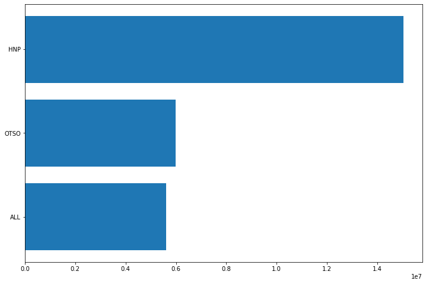

```python
df_hnp = senators_ranked_natl.loc[senators_ranked_natl['affil']=='HNP']
df_otso = senators_ranked_natl.loc[senators_ranked_natl['affil']=='OTSO']

ave_votes_hnp = int(df_hnp['votes'].mean())
ave_votes_otso = int(df_otso['votes'].mean())
ave_votes_all = int(senators['df']['votes'].mean())
print('"Hugpong Ng Pagbabago" average votes per candidate:\n',
      format(ave_votes_hnp, ','))
print('\n"Otso Diretso" average votes per candidate:\n',
      format(ave_votes_otso, ','))
print('\nAll candidates average votes:\n', format(ave_votes_all, ','))

votes_by_affil = sorter(['HNP', 'OTSO', 'ALL'],
                        [ave_votes_hnp, ave_votes_otso, ave_votes_all],
                        reverse=False)

fig, ax = plt.subplots(1, 1, figsize=(12, 8))
ax.barh(votes_by_affil[0], votes_by_affil[1])
plt.show()
```

#### ANALYSIS

The result shows that the average votes of an HNP candidate are more than double of the other candidates' votes. This shows that HNP Candidates, generally, are very popular among the voters.

### Number of Winners by Affiliation

Hugpong Ng Pagbabago  
Winners  
9

Otso Diretso  
Winners  
0

#### ANALYSIS

9 out of the Top 12 winners come from the HNP Group. Nobody from the OTSO Group was elected.

3 candidates from other groups (or Independent) made it to the Top 12.

### Median Ranking of Candidates by Affliation

A higher rank means more votes received.

```python
median_rank_hnp = round(np.median(df_hnp['rank']), 2)
median_rank_otso = round(np.median(df_otso['rank']), 2)
```

Hugpong Ng Pagbabago  
Median Rank  
9

Otso Diretso  
Median Rank  
24

#### ANALYSIS

The average ranking of HNP bets is below 10 which is just reflective of the result where majority of the Top 12 winners are from the HNP Group.

### Ranking Distributions by Affiliation

This code generates the Box Plot of the distribution of rankings of the candidates from the HNP and OTSO groups.

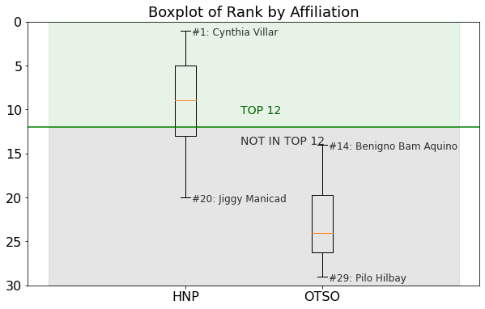

```python
affil_votes = senators_ranked_natl[['affil', 'votes', 'rank']]
affil_votes = affil_votes.loc\
    [(affil_votes['affil']=='HNP')|(affil_votes['affil']=='OTSO'), :]
fig, ax = plt.subplots(1, 1, figsize=(10, 6))

hnp_ranks = \
    list(affil_votes.pivot(columns='affil', values='rank')['HNP'].dropna())
otso_ranks = \
    list(affil_votes.pivot(columns='affil', values='rank')['OTSO'].dropna())

# ax = affil_votes.pivot(columns='affil', values='rank').boxplot(whis='range')
ax.boxplot((hnp_ranks, otso_ranks), labels=['HNP', 'OTSO'])
ax.set_title('Boxplot of Rank by Affiliation', fontsize=18)
ax.tick_params(labelsize=16)
ax.invert_yaxis()
ax.axhline(12, color='green')

ax.text(1.4, 10.5, 'TOP 12', fontsize=14, color='darkgreen')
ax.text(1.4, 14, 'NOT IN TOP 12', fontsize=14, color='black', alpha=0.8)
ax.text(1.05, 1.5, '#1: Cynthia Villar',
    fontsize=12, color='black', alpha=0.8)
ax.text(1.05, 20.5, '#20: Jiggy Manicad',
    fontsize=12, color='black', alpha=0.8)
ax.text(2.05, 14.5, '#14: Benigno Bam Aquino',
    fontsize=12, color='black', alpha=0.8)
ax.text(2.05, 29.5, '#29: Pilo Hilbay', fontsize=12,
    color='black', alpha=0.8)

ax.set_ylim(30, 0)
ax.fill_between([0, 3], 0, 12, zorder=0, alpha=0.1, color='forestgreen')
ax.fill_between([0, 3], 12, 30, zorder=0, alpha=0.2, color='gray')

fig.show()
```

#### ANALYSIS

For the 8 OTSO bets, they got the rank between 14 to 29 (inclusive). However, the distribution is skewed to the left, and although the best result was obtained by Bam Aquino (rank 14), most of the bets ranked much lower (20 or worse).

If basing only on the results of the election, it can be concluded that a majority of the Filipinos are satisfied with the administration. Meanwhile, the opposition has to strive harder or change its strategy if it wants to gain power in the 2022 elections.

## Story 2. Voter Turnout

The following code loads the data on the Total Registered Voters (expected) and the Total Actual Voters during the last 2019 Election (actual) per Region. The Percentage of Voter Turnout is also generated.

```python
turnout_r_df = results_r_df[[63, 64]]
turnout_r_df.columns = ['actual', 'expected']
percent_list = []
for ctr in range(18):
    percent_list.append(turnout_r_df.iloc[ctr]['actual'] / \
                        turnout_r_df.iloc[ctr]['expected'])
turnout_r_df['percent'] = percent_list
turnout_r_df.index.name = 'REGION'
```

```python
census_df = fetch_files()
```

```python
census_df_index_list = census_df.index
census_df_index_new_list = []
for census_df_index in census_df_index_list:

    matches = re.match(r'^_(.+?)_', census_df_index)
    if matches != None:
        match = matches.group(1)
    else:
        match = census_df_index
    if  match == 'MIMAROPA':
        census_df_index_new_list.append('REGION IV-B')
    elif match == 'CARAGA':
        census_df_index_new_list.append('REGION XIII')
    elif match == 'ARMM':
        census_df_index_new_list.append('BARMM')
    else:
        census_df_index_new_list.append(match)
census_df.index = census_df_index_new_list
census_df.index.name = 'REGION'
#
```

This code combined the Voter Turnout Data and the Census Data for all regions. Note that no Census Data is available for the Overseas Absentee Voting Group.

```python
region_statistics = pd.concat([turnout_r_df, census_df], axis=1, sort=True)
region_statistics = \
    region_statistics.where((pd.notnull(region_statistics)), 0)
```

### Voter Turnout by Region

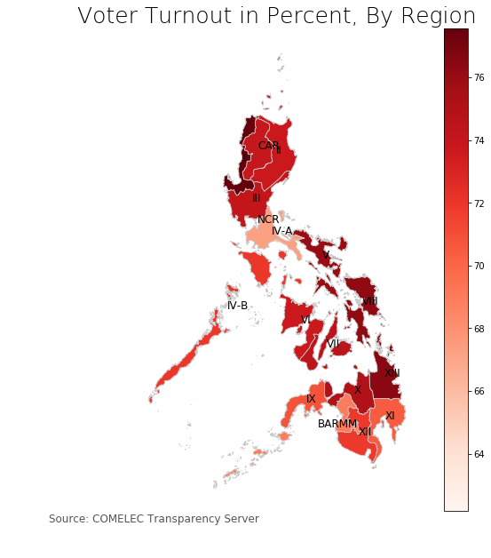

```python
def plot_turnout_ph(variable, merged, color):
    fig, ax = plt.subplots(1, figsize=(10, 10))
    merged.plot(column='percent', cmap=color,
                linewidth=0.8, ax=ax, edgecolor='0.8')

    for i, point in merged.centroid.iteritems():
        if 'REGION' in i:
            reg_n = i.split()[1]
        else:
            reg_n = i
        ax.text(s=reg_n, x=point.x, y=point.y, fontsize='large')

    ax.axis('off')
    ax.set_title('Voter Turnout in Percent, By Region'.format(variable),
                 fontdict={'fontsize': '25', 'fontweight' : '3'})
    ax.annotate('Source: COMELEC Transparency Server', xy=(0.1, .08),
                xycoords='figure fraction', horizontalalignment='left', verticalalignment='top', fontsize=12, color='#555555')

    sm = plt.cm.ScalarMappable(
        cmap=color, norm=plt.Normalize(vmin=merged['percent'].min(),
                                       vmax=merged['percent'].max()))
    sm._A = []
    cbar = fig.colorbar(sm)
    plt.show()

region_turnout_df = region_statistics['percent']*100
merged = map_df.set_index('REGION').join(region_turnout_df)
plot_turnout_ph(None, merged, 'Reds')
```

REGION I  
Highest Turnout - Ilocos Region  
77.56%

NCR  
Lowest Turnout - Metro Manila  
62.17%

#### ANALYSIS

Generally, there was a high voter turnout during the last election with most regions' turnout percentage at more than 70%. Aside from the Overseas Absentee Voting Group, NCR got the lowest turnout at 62%.

A high voter turnout shows that the government and the candidates were successful in creating wide awareness during the last election which increased the voters' desire to be part of this event that will shape the future of the country.

#### CALL TO ACTION

The government can use this data to identify areas where it should try harder to educate and persuade its citizens to vote.

Voting is a privilege, but it is also an obligation of each citizen to cast their vote and contribute to nation-building.

## Story 3. Literacy and Political Preference

### Literacy

Literacy means that the person can read, write and has basic understanding. 91% of the population 18 years old and higher are considered literate. This shows a high percentage of literacy in the country.

Is there a connection or correlation between the literacy in each region and that region's political preference (HNP or OTSO)?

This code displays the National Statistics on the Country's Population, Voter Registration, Voter Turnout, Voter Literacy and Voter Affiliation to INC.

```python
nation_statistics_l = {}
nation_statistics_l['actual'] = region_statistics['actual'].sum()
nation_statistics_l['expected'] = region_statistics['expected'].sum()
nation_statistics_l['total_pop'] = region_statistics['total_pop'].sum()
nation_statistics_l['eighteen_over'] = \
    region_statistics['eighteen_over'].sum()
nation_statistics_l['inc_members'] = region_statistics['inc_members'].sum()
nation_statistics_l['literacy'] = region_statistics['literacy'].sum()
print('PHILIPPINES STATISTICS')
print('----------------------')
print('Total Registered Voters        : {:11,}'\
      .format(nation_statistics_l['expected']))
print('Total Actual Voters            : {:11,}'\
      .format(nation_statistics_l['actual']))
print('Percent Voter Turnout          : {:6.2f}%'\
      .format(
    nation_statistics_l['actual']/nation_statistics_l['expected']*100))
print()
print('Total Population               : {:11,}'\
      .format(int(nation_statistics_l['total_pop'])))
print('Total 18y+ Population          : {:11,}'\
      .format(int(nation_statistics_l['eighteen_over'])))
print('Percent 18y+                   : {:6.2f}%'\
      .format(
    nation_statistics_l['eighteen_over']/nation_statistics_l['total_pop']*100))
print('Percent Registered (vs 18y+)   : {:6.2f}%'\
      .format(
    nation_statistics_l['expected']/nation_statistics_l['eighteen_over']*100))
print()
print('Total Literacy 18y+             : {:11,}'\
      .format(int(nation_statistics_l['literacy'])))
print('Percent Literacy 18y+           : {:6.2f}%'\
      .format(
    nation_statistics_l['literacy']/nation_statistics_l['eighteen_over']*100))
print()
# print('Total INC Members 18y+          : {:11,}'.format(int(nation_statistics_l['inc_members'])))
# print('Percent INC Members 18y+        : {:6.2f}%'.format(nation_statistics_l['inc_members']/nation_statistics_l['eighteen_over']*100))
```

```
PHILIPPINES STATISTICS
----------------------
Total Registered Voters        :  62,601,530
Total Actual Voters            :  44,279,204
Percent Voter Turnout          :  70.73%

Total Population               : 100,417,428
Total 18y+ Population          :  62,165,192
Percent 18y+                   :  61.91%
Percent Registered (vs 18y+)   : 100.70%

Total Literacy 18y+             :  56,815,461
Percent Literacy 18y+           :  91.39%
```

This data will be needed later on.

```python
rank_region_df = pd.DataFrame(rank_region_list)
rank_region_df.index = range(1,63)
# rank_region_df = rank_region_df.transpose()
rank_region_df.index.name = 'RANK'
# number under REGION is the CANDIDATE NUMBER sorted by RANK (index)

candidate_rank_region_list = {}
for region in region_list:
    r_list = []
    for ctr in range(1,63):
        r_list.append(
            rank_region_df.loc[rank_region_df[region] == ctr].index[0])
    candidate_rank_region_list[region] = r_list

candidate_rank_region_df = pd.DataFrame(candidate_rank_region_list)
candidate_rank_region_df.index = range(1,63)
candidate_rank_region_df.index.name = 'CANDIDATE'
# number under REGION is the RANK sorted by CANDIDATE NUMBER (index)
# candidate_rank_region_df
```

This code generates the succeeding graph which shows the number of winners from the following groups in each region: HNP Candidates, OTSO Candidates, and each region's Literacy Rate are overlaid in the graph.

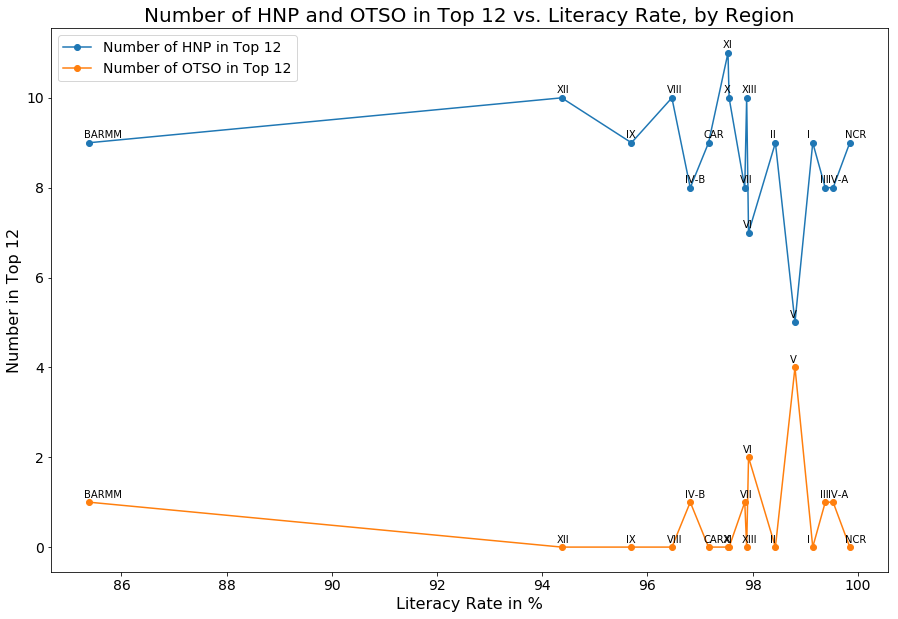

```python
plot1_data = winner_region_df['hnp'].drop(index='OAV')
plot2_data = winner_region_df['otso'].drop(index='OAV')
plot3_data = winner_region_df['inc'].drop(index='OAV')
plot4_data = region_statistics['inc_proportion'].drop(index='OAV')*100
plot5_data = region_statistics['literacy_proportion'].drop(index='OAV')*100
plot_label = list(plot4_data.index)
index = np.arange(len(plot_label))
bw = 0.30

labels_lit, lit_ascending = sorter(plot_label, plot5_data)
hnp_by_lit = [plot1_data[region] for region in labels_lit]
otso_by_lit = [plot2_data[region] for region in labels_lit]

fig, ax = plt.subplots(1, 1, figsize=(15,10))

ax.set_title('Number of HNP and OTSO in Top 12 vs. Literacy Rate, by Region',
            fontsize=20)
ax.plot(lit_ascending, hnp_by_lit, 'o-', label='Number of HNP in Top 12')
ax.plot(lit_ascending, otso_by_lit, 'o-', label='Number of OTSO in Top 12')
ax.set_xlabel('Literacy Rate in %', fontsize=16)
ax.set_ylabel('Number in Top 12', fontsize=16)
ax.tick_params(labelsize=14)
i = 0
for x, y, z in zip(lit_ascending, hnp_by_lit, otso_by_lit):
    ax.annotate(labels_lit[i].split()[-1], xy=(x-0.1, y+0.1))
    ax.annotate(labels_lit[i].split()[-1], xy=(x-0.1, z+0.1))
    i += 1

ax.legend(fontsize=14)
plt.show()
```

#### ANALYSIS

No connection can be seen between the region's literacy rate and the voting preference (HNP or OTSO).

However, on another note, it can be noticed that in regions where HNP got a higher number of seats, OTSO got a lower number, and vice-versa. It may be concluded that the voters are polarized in choosing between HNP and OTSO. This will be explored later.

## Story 4. Candidates' Performance by Region

As a candidate, you will want to know in which geographical areas you performed well or poorly in. Let us explore the performance of each winning candidate by region.

### Winners' Heatmaps

Each of the winners in the election fared differently depending on the geographic region. In this section, we will explore the proportion of voters in each region that voted for each of the winners.

The proportion is calculated as follows:

\begin{equation} P = \frac{V}{N} \cdot 100% \end{equation}

where V is the actual number who voted for a particular candidate, and N is the total number of voters in that region who actually voted.

The following codes display the heatmap proportion of votes each of the Top 12 winners' votes got across the country. The darker color shows the region where the candidates got their most proportion of votes.

```python
def plot_geo_ph(variable, merged, color):

#     vmin, vmax = 120, 220
    fig, ax = plt.subplots(1, figsize=(10, 10))
    merged.plot(column='PROP', cmap=color, linewidth=0.8, ax=ax,
                edgecolor='0.8')

    for i, point in merged.centroid.iteritems():
        if 'REGION' in i:
            reg_n = i.split()[1]
        else:
            reg_n = i
        ax.text(s=reg_n, x=point.x, y=point.y, fontsize='large')

    ax.axis('off')
    ax.set_title(
        'Proportion, in %, of Voters who Voted for {}, by Region'\
        .format(variable), fontdict={'fontsize': '25', 'fontweight' : '3'})
    ax.annotate('Source: COMELEC Transparency Server', xy=(0.1, .08),
                xycoords='figure fraction', horizontalalignment='left',
                verticalalignment='top', fontsize=12, color='#555555')

#     sm = plt.cm.ScalarMappable(cmap=color,
#                                norm=plt.Normalize(vmin=merged['PROP'].min(),
#                                                   vmax=merged['PROP'].max()))
    sm = plt.cm.ScalarMappable(cmap=color,
                               norm=plt.Normalize(vmin=0,
                                                  vmax=100))
    sm._A = []
    cbar = fig.colorbar(sm)
    plt.show()
#    fig.savefig('c62_votes_map.png', dpi=300)
```

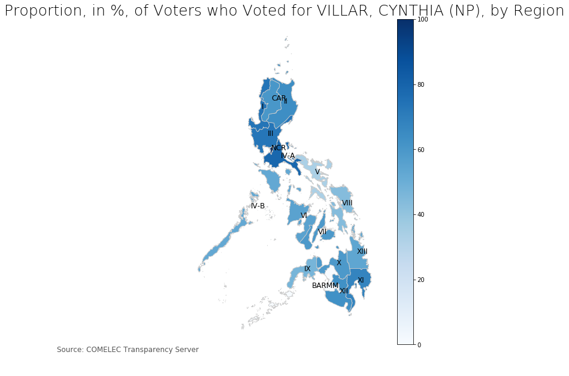

```python
senator_name = senator_list_rank[0]
idx = senator_list.index(senator_name)
vote_df = pd.DataFrame(results_r_df[idx+1]).reset_index()
vote_df.columns = ['REGION', 'VOTES']
merged = map_df.set_index('REGION').join(vote_df.set_index('REGION'))
proportion = [(merged['VOTES'][i] / region_statistics['actual'][i]) * \
              100 for i in merged.index]
merged['PROP'] = proportion
plot_geo_ph(senator_name, merged, 'Blues')
```

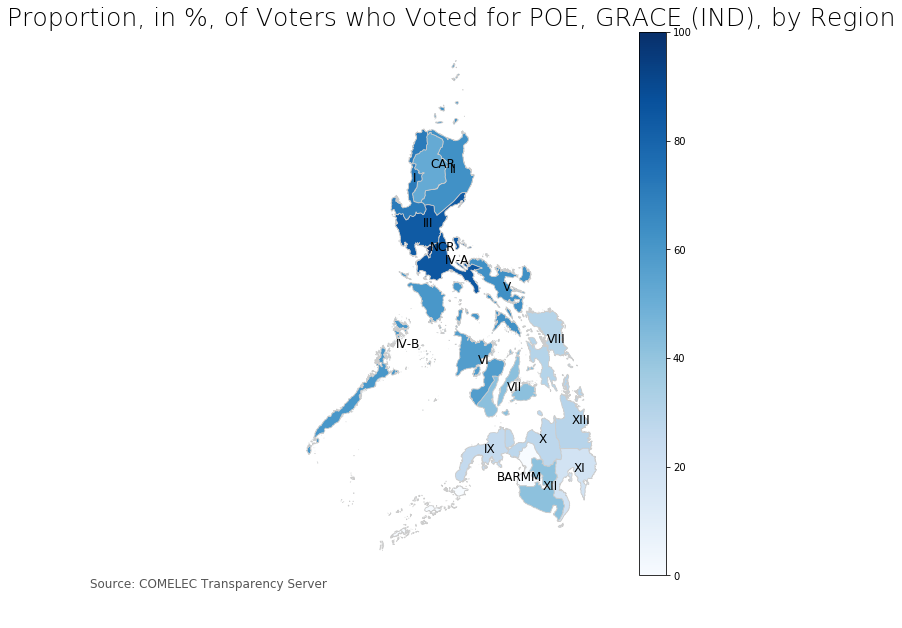

```python
senator_name = senator_list_rank[1]
idx = senator_list.index(senator_name)
vote_df = pd.DataFrame(results_r_df[idx+1]).reset_index()
vote_df.columns = ['REGION', 'VOTES']
merged = map_df.set_index('REGION').join(vote_df.set_index('REGION'))
proportion = [(merged['VOTES'][i] / region_statistics['actual'][i]) * \
              100 for i in merged.index]
merged['PROP'] = proportion
plot_geo_ph(senator_name, merged, 'Blues')
```

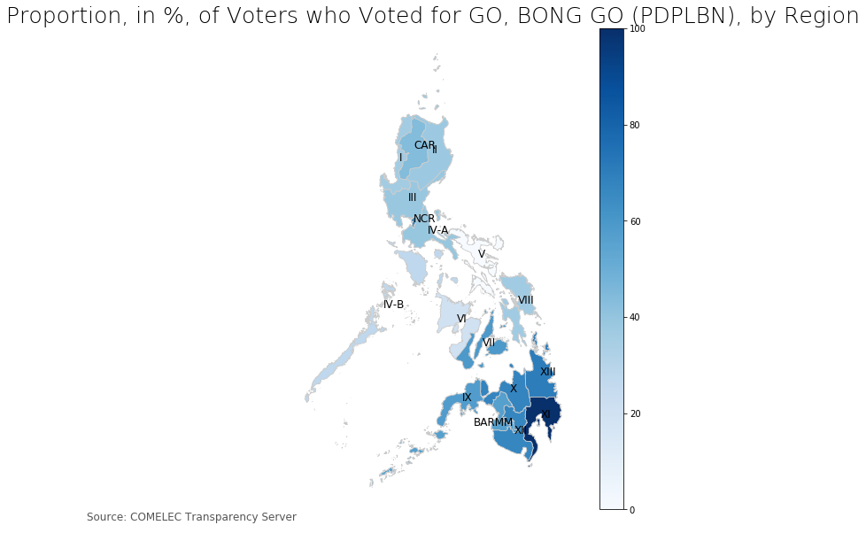

```python
senator_name = senator_list_rank[2]
idx = senator_list.index(senator_name)
vote_df = pd.DataFrame(results_r_df[idx+1]).reset_index()
vote_df.columns = ['REGION', 'VOTES']
merged = map_df.set_index('REGION').join(vote_df.set_index('REGION'))
proportion = [(merged['VOTES'][i] / region_statistics['actual'][i]) * 100 \
              for i in merged.index]
merged['PROP'] = proportion
plot_geo_ph(senator_name, merged, 'Blues')
```

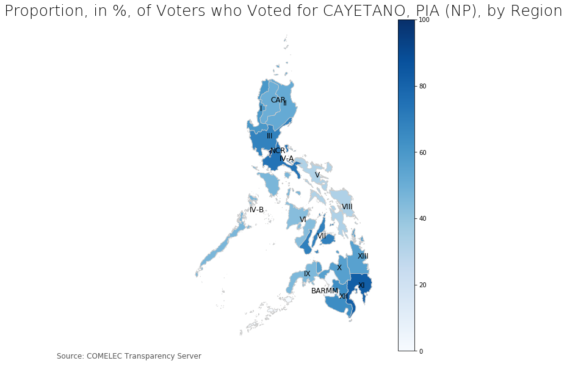

```python
senator_name = senator_list_rank[3]
idx = senator_list.index(senator_name)
vote_df = pd.DataFrame(results_r_df[idx+1]).reset_index()
vote_df.columns = ['REGION', 'VOTES']
merged = map_df.set_index('REGION').join(vote_df.set_index('REGION'))
proportion = [(merged['VOTES'][i] / region_statistics['actual'][i]) * 100 \
              for i in merged.index]
merged['PROP'] = proportion
plot_geo_ph(senator_name, merged, 'Blues')
```

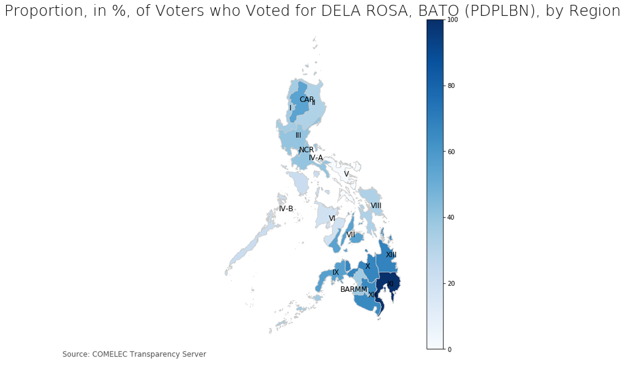

```python
senator_name = senator_list_rank[4]
idx = senator_list.index(senator_name)
vote_df = pd.DataFrame(results_r_df[idx+1]).reset_index()
vote_df.columns = ['REGION', 'VOTES']
merged = map_df.set_index('REGION').join(vote_df.set_index('REGION'))
proportion = [(merged['VOTES'][i] / region_statistics['actual'][i]) * 100 \
              for i in merged.index]
merged['PROP'] = proportion
plot_geo_ph(senator_name, merged, 'Blues')
```

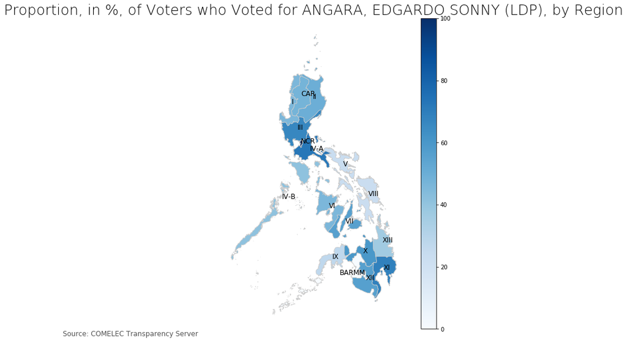

```python
senator_name = senator_list_rank[5]
idx = senator_list.index(senator_name)
vote_df = pd.DataFrame(results_r_df[idx+1]).reset_index()
vote_df.columns = ['REGION', 'VOTES']
merged = map_df.set_index('REGION').join(vote_df.set_index('REGION'))
proportion = [(merged['VOTES'][i] / region_statistics['actual'][i]) * 100 \
              for i in merged.index]
merged['PROP'] = proportion
plot_geo_ph(senator_name, merged, 'Blues')
```

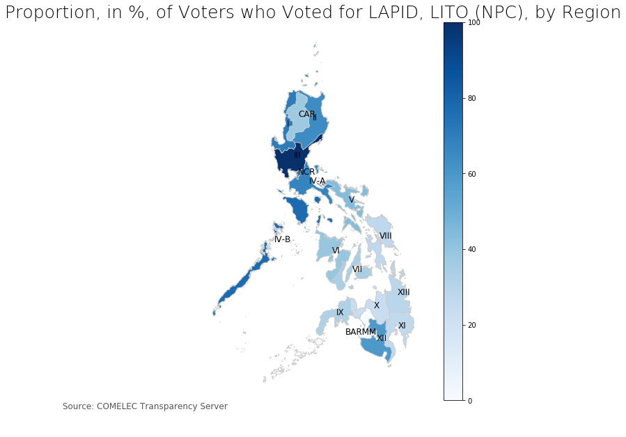

```python
senator_name = senator_list_rank[6]
idx = senator_list.index(senator_name)
vote_df = pd.DataFrame(results_r_df[idx+1]).reset_index()
vote_df.columns = ['REGION', 'VOTES']
merged = map_df.set_index('REGION').join(vote_df.set_index('REGION'))
proportion = [(merged['VOTES'][i] / region_statistics['actual'][i]) * 100 \
              for i in merged.index]
merged['PROP'] = proportion
plot_geo_ph(senator_name, merged, 'Blues')
```

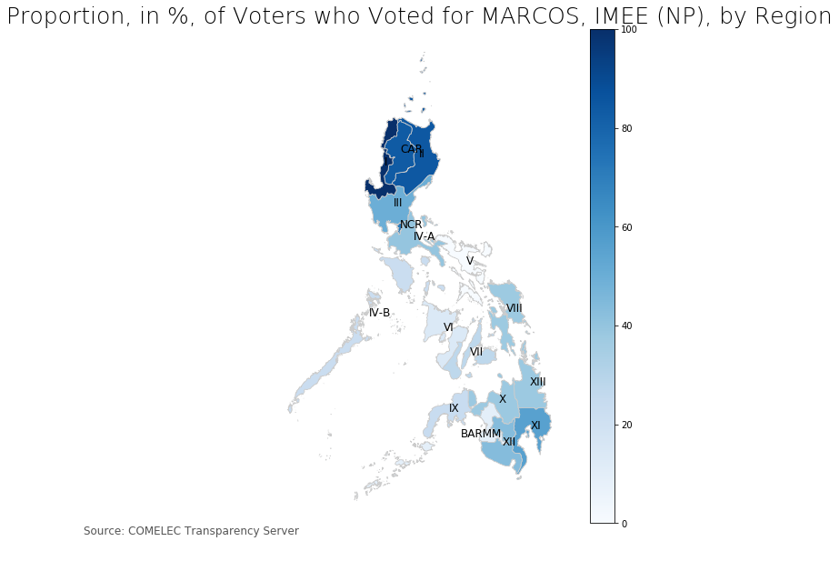

```python
senator_name = senator_list_rank[7]
idx = senator_list.index(senator_name)
vote_df = pd.DataFrame(results_r_df[idx+1]).reset_index()
vote_df.columns = ['REGION', 'VOTES']
merged = map_df.set_index('REGION').join(vote_df.set_index('REGION'))
proportion = [(merged['VOTES'][i] / region_statistics['actual'][i]) * 100 \
              for i in merged.index]
merged['PROP'] = proportion
plot_geo_ph(senator_name, merged, 'Blues')
```

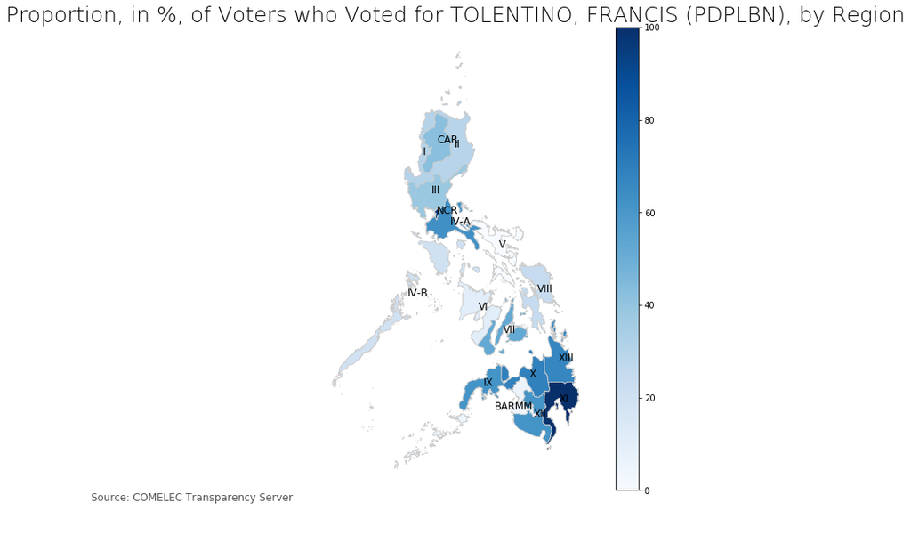

```python
senator_name = senator_list_rank[8]
idx = senator_list.index(senator_name)
vote_df = pd.DataFrame(results_r_df[idx+1]).reset_index()
vote_df.columns = ['REGION', 'VOTES']
merged = map_df.set_index('REGION').join(vote_df.set_index('REGION'))
proportion = [(merged['VOTES'][i] / region_statistics['actual'][i]) * 100 \
              for i in merged.index]
merged['PROP'] = proportion
plot_geo_ph(senator_name, merged, 'Blues')
```

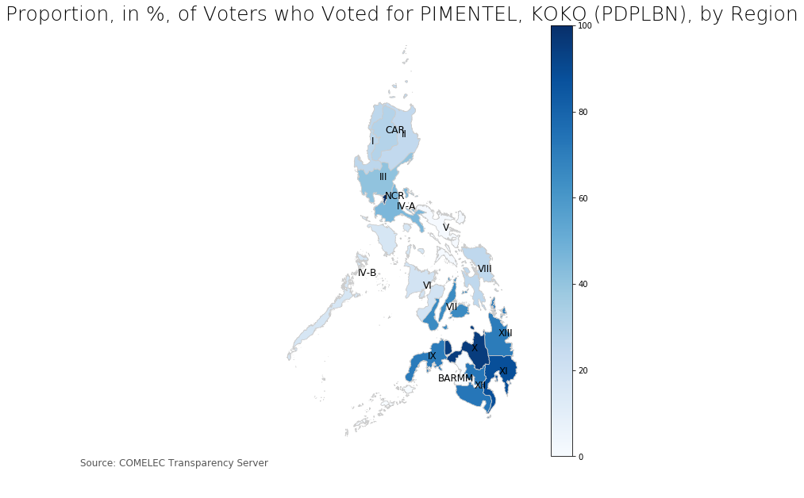

```python
senator_name = senator_list_rank[9]
idx = senator_list.index(senator_name)
vote_df = pd.DataFrame(results_r_df[idx+1]).reset_index()
vote_df.columns = ['REGION', 'VOTES']
merged = map_df.set_index('REGION').join(vote_df.set_index('REGION'))
proportion = [(merged['VOTES'][i] / region_statistics['actual'][i]) * 100 \
              for i in merged.index]
merged['PROP'] = proportion
plot_geo_ph(senator_name, merged, 'Blues')
```

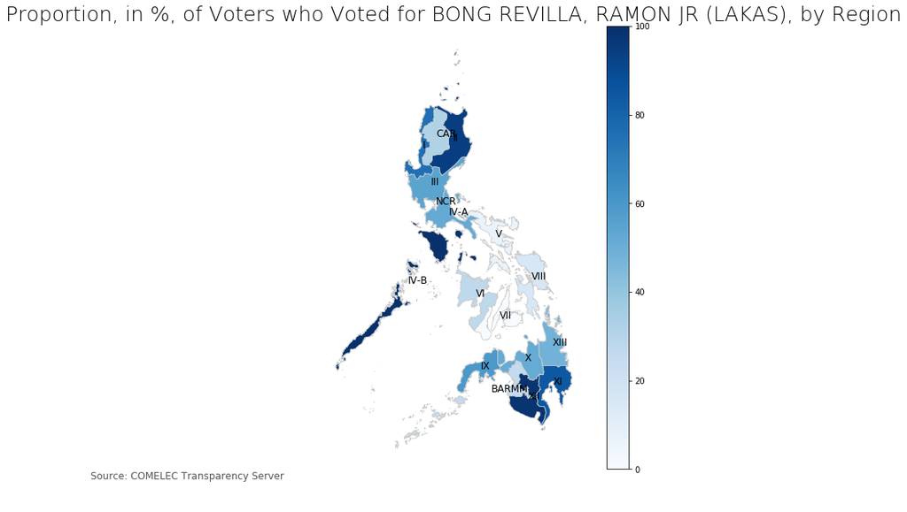

```python
senator_name = senator_list_rank[10]
idx = senator_list.index(senator_name)
vote_df = pd.DataFrame(results_r_df[idx+1]).reset_index()
vote_df.columns = ['REGION', 'VOTES']
merged = map_df.set_index('REGION').join(vote_df.set_index('REGION'))
proportion = [(merged['VOTES'][i] / region_statistics['actual'][i]) * 100 \
              for i in merged.index]
merged['PROP'] = proportion
plot_geo_ph(senator_name, merged, 'Blues')
```

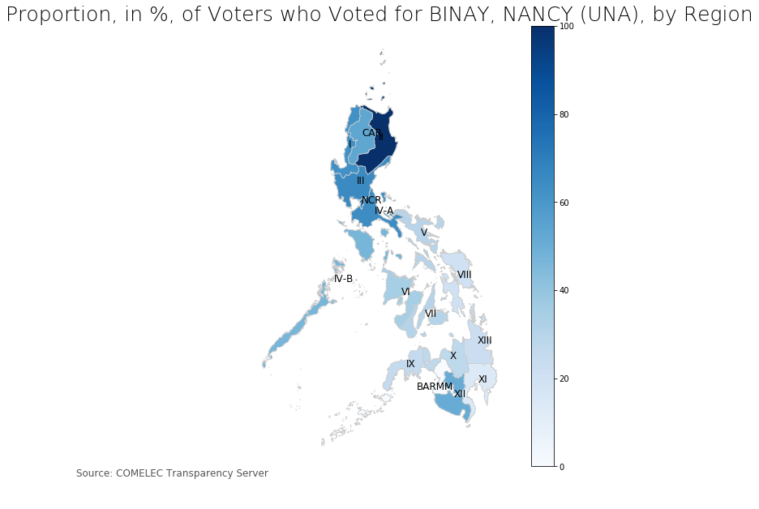

```python
senator_name = senator_list_rank[11]
idx = senator_list.index(senator_name)
vote_df = pd.DataFrame(results_r_df[idx+1]).reset_index()
vote_df.columns = ['REGION', 'VOTES']
merged = map_df.set_index('REGION').join(vote_df.set_index('REGION'))
proportion = [(merged['VOTES'][i] / region_statistics['actual'][i]) * 100 \
              for i in merged.index]
merged['PROP'] = proportion
plot_geo_ph(senator_name, merged, 'Blues')
```

#### ANALYSIS

This information can be used by the losing (and even winning) candidates to see their rank on each region and to know which region they need to work on to improve their image, reputation and/or popularity. **This can be useful information particularly if the candidate is planning to run in future elections.**

The Top 12 winners have been consistently on top of the race in almost all regions. Though, some of the Top 12 candidates did not perform well in some regions but these are just a few regions. This means that to be a winner, the candidate must be consistent in gaining most of the votes in all regions (or at least, in most regions) and not just be on the top in a few regions. This tells the candidates to work on getting the votes of all citizens of the whole country, from Aparri to Jolo, and to not disregard any part of the country.

## Story 5. Performance of HNP and OTSO by Region

Let us widen our scope a little and take a look at the performance of the HNP and OTSO by region.

### Heatmaps by Affiliation (HNP or OTSO)

The succeeding codes generate the heatmap showing on the number of candidates of each group who made it to the Top 12 winners per region.

The darker the color of the region shows that the voters of the region are more aligned to the group (or to the candidates of the group). This also shows the populaty of the group (or its candidates) in the region.

HNP or OTSO can work on awareness campaign and developing a better campaign strategy in the ligher shaded regions to improve the voters' sentiment and awareness of the group. This can be a preparation for future elections.

```python
def plot_affil_ph(variable, merged, color, filename):

#     vmin, vmax = 120, 220
    fig, ax = plt.subplots(1, figsize=(10, 10))
    merged.plot(column='VOTES', cmap=color, linewidth=0.8, ax=ax,
                edgecolor='0.8')

    for i, point in merged.centroid.iteritems():
        if 'REGION' in i:
            reg_n = i.split()[1]
        else:
            reg_n = i
        ax.text(s=reg_n, x=point.x, y=point.y, fontsize='large')

    ax.axis('off')


    sm = plt.cm.ScalarMappable(cmap=color,
                               norm=plt.Normalize(vmin=merged['VOTES'].min(),
                                                  vmax=merged['VOTES'].max()))

    fig.savefig(filename, dpi=300)

    ax.set_title('Number of Candidates in Top 12 of {}, by Region'\
                 .format(variable),
                 fontdict={'fontsize': '25', 'fontweight': '3'})
    ax.annotate('Source: COMELEC Transparency Server', xy=(0.1, .08),
                xycoords='figure fraction', horizontalalignment='left',
                verticalalignment='top', fontsize=12, color='#555555')
    sm._A = []
    cbar = fig.colorbar(sm)

    plt.show()
```

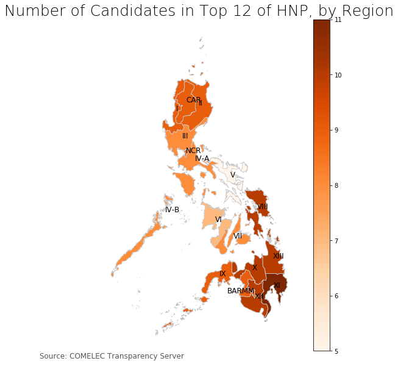

```python
vote_df = pd.DataFrame(winner_region_df['hnp']).reset_index()
vote_df.columns = ['REGION', 'VOTES']
merged = map_df.set_index('REGION').join(vote_df.set_index('REGION'))
plot_affil_ph('HNP', merged, 'Oranges', filename='figures/hnp_votes_map.png')
```

#### ANALYSIS

In all regions, at least 5 candidates of the HNP bets were part of the Top 12. There were even regions with up to 11 HNP candidates who got into the Top 12. This shows that HNP is now a strong Political Group in the country who can make winners in the national election. This is an alliance to consider for politicians who have no strong party loyalty.

It can be observed that HNP achieved its best rankings towards the south of the country (Mindanao and REGION VIII), and performed decently in the North (REGION I, II, CAR)

If the HNP intend to maintain power in 2022, they might want to focus on regions where they are weaker such as REGION V and REGION VI.

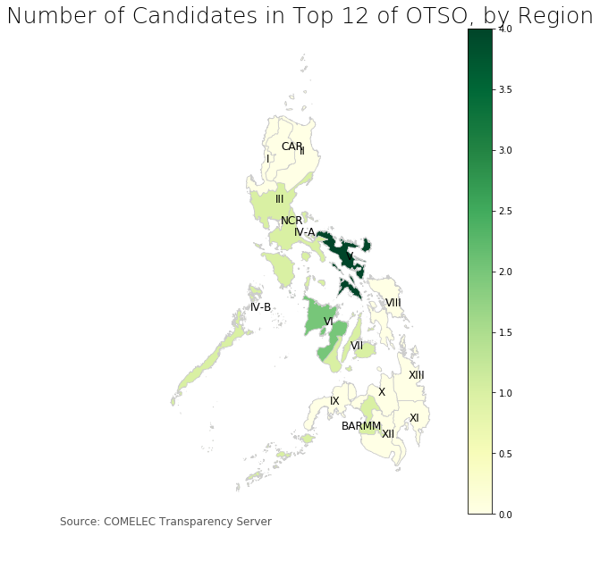

```python
vote_df = pd.DataFrame(winner_region_df['otso']).reset_index()
vote_df.columns = ['REGION', 'VOTES']
merged = map_df.set_index('REGION').join(vote_df.set_index('REGION'))
plot_affil_ph('OTSO', merged, 'YlGn', filename='figures/otso_votes_map.png')
```

#### ANALYSIS

OTSO bets performed poorly in the last election. There were even regions where no OTSO bet was part of the Top 12. At most, only 4 OTSO bets were included in the Top 12 of some regions. This shows that the party (and/or its candidates) has a low reputation and popularity with the voters. If the OTSO want to gain power in 2022, they have to do something to change the voters' sentiment and awareness of the OTSO party and its mission.

### Side-by-side Comparison

```python
display(HTML("<table><tr><td><img src='figures/hnp_votes_map.png'></td><td>" +\
             "<img src='figures/otso_votes_map.png'></td></tr></table>"))
```

[output not shown]

#### ANALYSIS

The two graphs are somewhat complementary, this shows that the voters are polarized between HNP and OTSO (they will only vote for one or the other. This worked in favor of the HNP.

## Story 6. Influence of the INC

About 4% of the voting population of the country are members of the INC Religious Group. Though this can be considered a small group, the INC Group can be a significant force in any election if the other bigger groups are not united and do not act collectively as a group.

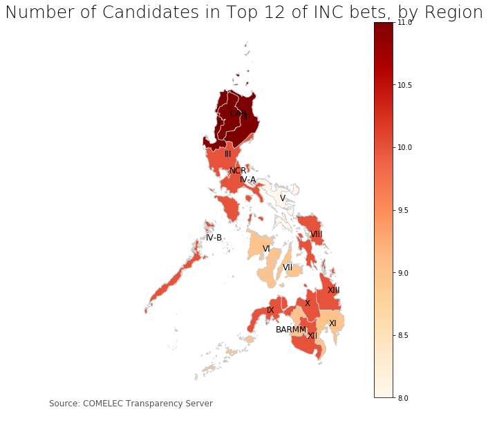

```python
vote_df = pd.DataFrame(winner_region_df['inc']).reset_index()
vote_df.columns = ['REGION', 'VOTES']
merged = map_df.set_index('REGION').join(vote_df.set_index('REGION'))
plot_affil_ph('INC bets', merged, 'OrRd', 'figures/inc_votes_map.png')
```

This code generates the graph showing the number of winner (in the Top 12) categorized by Religious Group Endorsement.

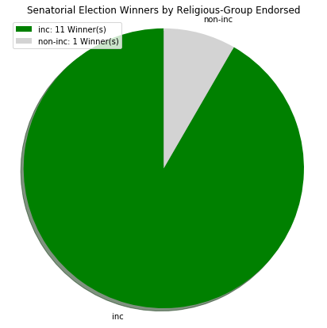

```python
fig, ax = plt.subplots(1, 1, figsize=(7,7))
labels = list(winner_nation_df.iloc[0].index[2:3])
labels.append('non-inc')
sizes = list(winner_nation_df.iloc[0].values[2:3])
sizes.append(12-sizes[0])
colors = ['green', 'lightgray']
explode = (0, 0)  # explode 1st slice

# Plot
plt.pie(sizes, explode=explode, labels=labels, colors=colors, shadow=True,
        startangle=90)
plt.axis('equal')
plt.legend(labels=['{}: {} Winner(s)'.format(l, s) \
                   for l, s in zip(labels, sizes)], loc="best")

plt.title('Senatorial Election Winners by Religious-Group Endorsed')
plt.show()
```

#### ANALYSIS

11 of the 12 candidates endorsed by INC Religious Group made it to the Top 12. This shows that candidates endorsed by INC tend to run successfully.

INC is another strong force during elections. Even though it is a minority group in the overall population, INC members are believed to vote collectively as guided by their leaders during elections. With the result of the recent election, 11 of the 12 candidates who the INC endorsed got into the Top 12. In the first place, the result shows that INC makes a good decision in selecting the winnable candidates. Further, INC's endorsement is considered to have an effect on the winnability of the candidate. Therefore, future candidates (as with previous election's candidates) should consider getting the endorsement of religious group especially the INC.

## Story 7. The Home-Court Advantage

### Home-Court Advantage

Many candidates enjoy the so-called 'Home-Court Advantage', which means that they will tend to gain more votes from the Municipalities, Provinces, and/or Regions that they reside in, or originate from.

We will take a look at how the home-court advantage worked for some selected candidates.

This code generates the Provincial Level and the City Level results of the election.

```python
results_p_df = results_df.groupby(['province'])\
    .agg(dict(zip(list(range(1,65)), ['sum']*64)))
results_c_df = results_df.groupby(['city'])\
    .agg(dict(zip(list(range(1,65)), ['sum']*64)))
```

The following codes test the Home-Court Advantage hypothesis whether it helped the candidates during the last election.

### San Juan City

San Juan City is the home city of the Estradas (Ejercitos).

```python
result_sanjuancity = pd.DataFrame(results_c_df.loc['SAN JUAN CITY'][0:62])
result_sanjuancity.sort_values('SAN JUAN CITY', ascending=False, inplace=True)
name_list = []
for index, value in result_sanjuancity.iterrows():
    name_list.append(senator_list[index-1])
result_sanjuancity['NAME'] = name_list
result_sanjuancity['BOC'] = result_sanjuancity.index
result_sanjuancity['rank'] = range(1,63)
result_sanjuancity.set_index('rank', inplace=True)
result_sanjuancity[:15]
```

| rank | SAN JUAN CITY | NAME | BOC |
| --- | --- | --- | --- |
| 1 | 36236 | POE, GRACE (IND) | 55 |
| 2 | 34923 | VILLAR, CYNTHIA (NP) | 62 |
| 3 | 32851 | EJERCITO, ESTRADA JV (NPC) | 26 |
| 4 | 30409 | GO, BONG GO (PDPLBN) | 34 |
| 5 | 29235 | ANGARA, EDGARDO SONNY (LDP) | 8 |
| 6 | 28841 | CAYETANO, PIA (NP) | 19 |
| 7 | 28555 | DELA ROSA, BATO (PDPLBN) | 24 |
| 8 | 25007 | TOLENTINO, FRANCIS (PDPLBN) | 60 |
| 9 | 25004 | MARCOS, IMEE (NP) | 46 |
| 10 | 24009 | PIMENTEL, KOKO (PDPLBN) | 54 |
| 11 | 23271 | ONG, DOC WILLIE (LAKAS) | 51 |
| 12 | 21922 | AQUINO, BENIGNO BAM (LP) | 9 |
| 13 | 20858 | ESTRADA, JINGGOY (PMP) | 29 |
| 14 | 19541 | BINAY, NANCY (UNA) | 15 |
| 15 | 18220 | LAPID, LITO (NPC) | 40 |

#### ANALYSIS

The result shows that JV Ejercito ranked # 3 and Jinggoy Estrada ranked # 13 in the city of San Juan during the last election.

The home-court advantage worked for JV Ejercito, but clearly, it did not work that well for Jinggoy Estrada.

### Makati City

Makati City is the home city of the Binays.

```python
result_cityofmakati = pd.DataFrame(results_c_df.loc['CITY OF MAKATI'][0:62])
result_cityofmakati.sort_values('CITY OF MAKATI', ascending=False,
                                inplace=True)
name_list = []
for index, value in result_cityofmakati.iterrows():
    name_list.append(senator_list[index-1])
result_cityofmakati['NAME'] = name_list
result_cityofmakati['BOC'] = result_cityofmakati.index
result_cityofmakati['rank'] = range(1,63)
result_cityofmakati.set_index('rank', inplace=True)
result_cityofmakati[:15]
```

| rank | CITY OF MAKATI | NAME | BOC |
| --- | --- | --- | --- |
| 1 | 202603 | VILLAR, CYNTHIA (NP) | 62 |
| 2 | 200415 | BINAY, NANCY (UNA) | 15 |
| 3 | 181481 | POE, GRACE (IND) | 55 |
| 4 | 161916 | CAYETANO, PIA (NP) | 19 |
| 5 | 161243 | ANGARA, EDGARDO SONNY (LDP) | 8 |
| 6 | 153394 | GO, BONG GO (PDPLBN) | 34 |
| 7 | 153392 | DELA ROSA, BATO (PDPLBN) | 24 |
| 8 | 150045 | MARCOS, IMEE (NP) | 46 |
| 9 | 136717 | TOLENTINO, FRANCIS (PDPLBN) | 60 |
| 10 | 128155 | PIMENTEL, KOKO (PDPLBN) | 54 |
| 11 | 126430 | ONG, DOC WILLIE (LAKAS) | 51 |
| 12 | 120327 | EJERCITO, ESTRADA JV (NPC) | 26 |
| 13 | 117288 | AQUINO, BENIGNO BAM (LP) | 9 |
| 14 | 105881 | OSMEÑA, SERGE (IND) | 52 |
| 15 | 102875 | LAPID, LITO (NPC) | 40 |

#### ANALYSIS

Binay got the rank of # 2 in Makati City. The home court-advantage did work for Nancy Binay.

### Capiz

Capiz is the home province of the Roxases.

```python
result_capiz = pd.DataFrame(results_p_df.loc['CAPIZ'][0:62])
result_capiz.sort_values('CAPIZ', ascending=False, inplace=True)
name_list = []
for index, value in result_capiz.iterrows():
    name_list.append(senator_list[index-1])
result_capiz['NAME'] = name_list
result_capiz['BOC'] = result_capiz.index
result_capiz['rank'] = range(1,63)
result_capiz.set_index('rank', inplace=True)
result_capiz[:15]
```

| rank | CAPIZ | NAME | BOC |
| --- | --- | --- | --- |
| 1 | 190481 | ROXAS, MAR (LP) | 57 |
| 2 | 177568 | VILLAR, CYNTHIA (NP) | 62 |
| 3 | 156305 | POE, GRACE (IND) | 55 |
| 4 | 141380 | AQUINO, BENIGNO BAM (LP) | 9 |
| 5 | 128661 | BONG REVILLA, RAMON JR (LAKAS) | 16 |
| 6 | 127772 | LAPID, LITO (NPC) | 40 |
| 7 | 125679 | GO, BONG GO (PDPLBN) | 34 |
| 8 | 122839 | CAYETANO, PIA (NP) | 19 |
| 9 | 116691 | ANGARA, EDGARDO SONNY (LDP) | 8 |
| 10 | 106587 | BINAY, NANCY (UNA) | 15 |
| 11 | 105278 | DELA ROSA, BATO (PDPLBN) | 24 |
| 12 | 85317 | PIMENTEL, KOKO (PDPLBN) | 54 |
| 13 | 84475 | ESTRADA, JINGGOY (PMP) | 29 |
| 14 | 84032 | TOLENTINO, FRANCIS (PDPLBN) | 60 |
| 15 | 78650 | EJERCITO, ESTRADA JV (NPC) | 26 |

#### ANALYSIS

Mar Roxas was number 1 in Capiz and thus the home court-advantage worked for Mar Roxas.

### Region I

Region I is where the locals are loyal to the Marcoses.

```python
result_regioni = pd.DataFrame(results_r_df.loc['REGION I'][0:62])
result_regioni.sort_values('REGION I', ascending=False, inplace=True)
name_list = []
for index, value in result_regioni.iterrows():
    name_list.append(senator_list[index-1])
result_regioni['NAME'] = name_list
result_regioni['BOC'] = result_regioni.index
result_regioni['rank'] = range(1,63)
result_regioni.set_index('rank', inplace=True)
result_regioni[:15]
```

| rank | REGION I | NAME | BOC |
| --- | --- | --- | --- |
| 1 | 1660723 | MARCOS, IMEE (NP) | 46 |
| 2 | 1563796 | VILLAR, CYNTHIA (NP) | 62 |
| 3 | 1415639 | POE, GRACE (IND) | 55 |
| 4 | 1135301 | CAYETANO, PIA (NP) | 19 |
| 5 | 1133754 | LAPID, LITO (NPC) | 40 |
| 6 | 1058716 | GO, BONG GO (PDPLBN) | 34 |
| 7 | 979804 | BONG REVILLA, RAMON JR (LAKAS) | 16 |
| 8 | 972701 | ANGARA, EDGARDO SONNY (LDP) | 8 |
| 9 | 963732 | BINAY, NANCY (UNA) | 15 |
| 10 | 962238 | DELA ROSA, BATO (PDPLBN) | 24 |
| 11 | 806870 | EJERCITO, ESTRADA JV (NPC) | 26 |
| 12 | 775449 | TOLENTINO, FRANCIS (PDPLBN) | 60 |
| 13 | 757729 | ESTRADA, JINGGOY (PMP) | 29 |
| 14 | 725509 | PIMENTEL, KOKO (PDPLBN) | 54 |
| 15 | 644612 | AQUINO, BENIGNO BAM (LP) | 9 |

#### ANALYSIS

Certainly, the home-court advantage worked for Imee Marcos who was number 1 in the region.

### Pampanga

Lito Lapid is a resident of Pampanga Province.

```python
result_pampanga = pd.DataFrame(results_p_df.loc['PAMPANGA'][0:62])
result_pampanga.sort_values('PAMPANGA', ascending=False, inplace=True)
name_list = []
for index, value in result_pampanga.iterrows():
    name_list.append(senator_list[index-1])
result_pampanga['NAME'] = name_list
result_pampanga['BOC'] = result_pampanga.index
result_pampanga['rank'] = range(1,63)
result_pampanga.set_index('rank', inplace=True)
result_pampanga[:15]
```

| rank | PAMPANGA | NAME | BOC |
| --- | --- | --- | --- |
| 1 | 746328 | LAPID, LITO (NPC) | 40 |
| 2 | 693203 | VILLAR, CYNTHIA (NP) | 62 |
| 3 | 576520 | POE, GRACE (IND) | 55 |
| 4 | 516577 | CAYETANO, PIA (NP) | 19 |
| 5 | 481637 | GO, BONG GO (PDPLBN) | 34 |
| 6 | 461006 | DELA ROSA, BATO (PDPLBN) | 24 |
| 7 | 416538 | ANGARA, EDGARDO SONNY (LDP) | 8 |
| 8 | 366206 | BONG REVILLA, RAMON JR (LAKAS) | 16 |
| 9 | 363847 | MARCOS, IMEE (NP) | 46 |
| 10 | 357663 | BINAY, NANCY (UNA) | 15 |
| 11 | 356072 | TOLENTINO, FRANCIS (PDPLBN) | 60 |
| 12 | 342388 | AQUINO, BENIGNO BAM (LP) | 9 |
| 13 | 334995 | PIMENTEL, KOKO (PDPLBN) | 54 |
| 14 | 320381 | EJERCITO, ESTRADA JV (NPC) | 26 |
| 15 | 297351 | MANICAD, JIGGY (IND) | 45 |

#### ANALYSIS

Lito Lapid got the most votes in Pampanga Province and thus the home court-advantage worked for him.

### Cavite

Cavite is the province of Bong Revilla.

```python
result_cavite = pd.DataFrame(results_p_df.loc['CAVITE'][0:62])
result_cavite.sort_values('CAVITE', ascending=False, inplace=True)
name_list = []
for index, value in result_cavite.iterrows():
    name_list.append(senator_list[index-1])
result_cavite['NAME'] = name_list
result_cavite['BOC'] = result_cavite.index
result_cavite['rank'] = range(1,63)
result_cavite.set_index('rank', inplace=True)
result_cavite[:15]
```

| rank | CAVITE | NAME | BOC |
| --- | --- | --- | --- |
| 1 | 898346 | VILLAR, CYNTHIA (NP) | 62 |
| 2 | 815347 | POE, GRACE (IND) | 55 |
| 3 | 755596 | TOLENTINO, FRANCIS (PDPLBN) | 60 |
| 4 | 739436 | CAYETANO, PIA (NP) | 19 |
| 5 | 677959 | GO, BONG GO (PDPLBN) | 34 |
| 6 | 668774 | ANGARA, EDGARDO SONNY (LDP) | 8 |
| 7 | 643585 | DELA ROSA, BATO (PDPLBN) | 24 |
| 8 | 579423 | BONG REVILLA, RAMON JR (LAKAS) | 16 |
| 9 | 560758 | MARCOS, IMEE (NP) | 46 |
| 10 | 546091 | EJERCITO, ESTRADA JV (NPC) | 26 |
| 11 | 535446 | LAPID, LITO (NPC) | 40 |
| 12 | 495974 | BINAY, NANCY (UNA) | 15 |
| 13 | 494903 | AQUINO, BENIGNO BAM (LP) | 9 |
| 14 | 481824 | PIMENTEL, KOKO (PDPLBN) | 54 |
| 15 | 449149 | ONG, DOC WILLIE (LAKAS) | 51 |

#### ANALYSIS

Bong Revilla was number 8 only in Cavite and thus the home court-advantage did not work as well for him.

As shown by these tests, candidates should never just rely on the home court-advantage hypothesis because it works with some but not all. As mentioned earlier, candidates should work in campaigning on all regions, provinces, cities and municipalities in the whole country and should try not to miss any (most importantly, not to skip the home court). The home court advantage works depending on the image and reputation of the candidate (and/or his/her family) and also on how deep the loyalty of the people to the candidate and/or to his/her family.